# Markov Chain Monte Carlo

Matthew Talluto

04.05.2022

# Laplace approximation isn’t always effective

- Complex models (e.g., hierarchical models)
  - Model height as a function of weight
  - People from rich countries are taller on average

$$\begin{aligned}
\bar{h}_{country} & \sim \mathcal{N}(A + B \times income_{country}, \Sigma) \\
h & \sim \mathcal{N}(\bar{h}_{country} + b \times weight, \sigma)
\end{aligned}$$

# Laplace approximation isn’t always effective

- Complex models (e.g., hierarchical models)
  - Model height as a function of weight
  - People from rich countries are taller on average
- Poorly identified models
  - correlated predictors
  - very flat posterior distributions
  - small sample sizes
  - very weak priors

$$\begin{aligned}
\bar{h}_{country} & \sim \mathcal{N}(A + B \times income_{country}, \Sigma) \\
h & \sim \mathcal{N}(\bar{h}_{country} + b \times weight, \sigma)
\end{aligned}$$

# Laplace approximation isn’t always effective

- Complex models (e.g., hierarchical models)
  - Model height as a function of weight
  - People from rich countries are taller on average
- Poorly identified models
  - correlated predictors
  - very flat posterior distributions
  - small sample sizes
  - very weak priors
- Highly skewed distributions

$$\begin{aligned}
\bar{h}_{country} & \sim \mathcal{N}(A + B \times income_{country}, \Sigma) \\
h & \sim \mathcal{N}(\bar{h}_{country} + b \times weight, \sigma)
\end{aligned}$$

# The German Tank Problem

- During WW2, the Allies wanted to know the rate of tank production in German factories
- Known: factories stamped serial numbers on the tanks in order, starting with 1
- The problem: given a set of captured serial numbers $s$, estimate $N$, the maximum serial number

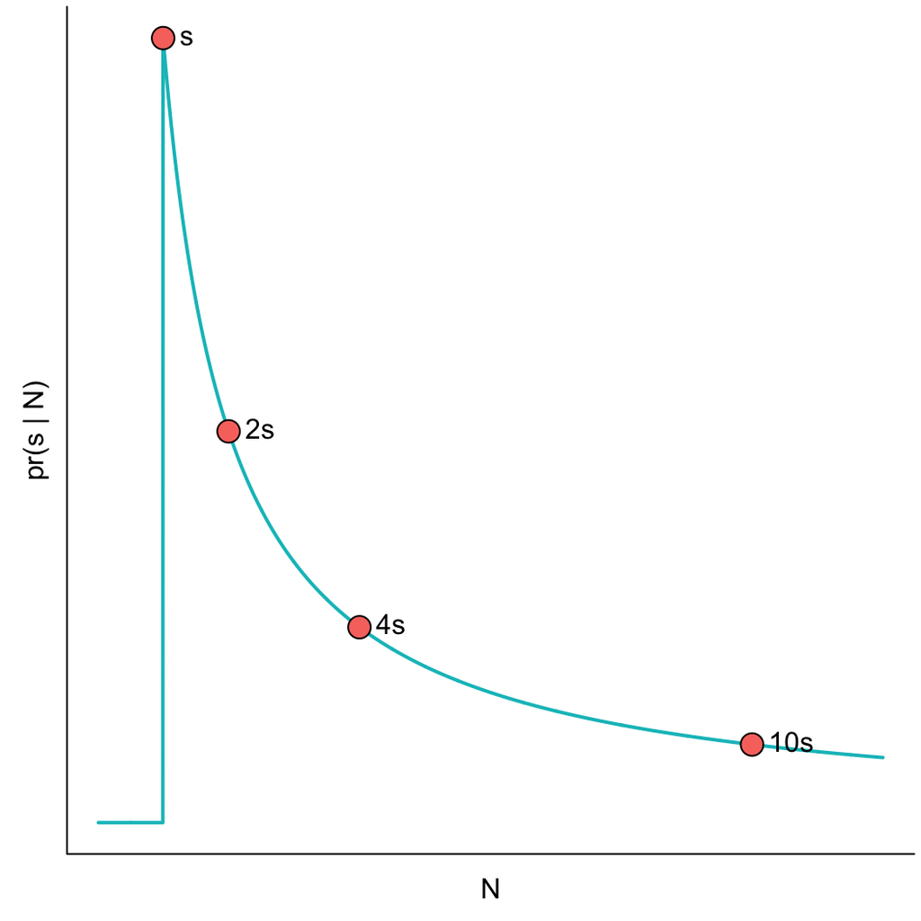

# Rejection sampling

- There are general algorithms for sampling from unknown distributions
- We have the **target distribution**, $t(N) = pr(s|N)$
- Find an easy-to-sample **proposal distribution**, call it $f(N)$,
  - Scale it so that it’s always higher than our target
  - Uniform is an obvious choice here, with a very high maximum: e.g., `dunif(s, 1, 1e6)`
  - This is a kind of prior - we are saying that it’s impossible they made more than a million tanks

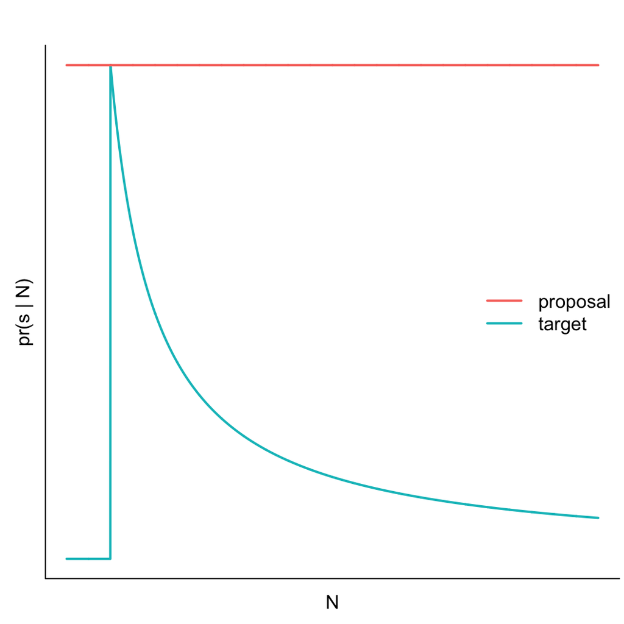

# Rejection sampling

- There are general algorithms for sampling from unknown distributions
- We have the **target distribution**, $t(N) = pr(s|N)$
- Find an easy-to-sample **proposal distribution**, call it $f(N)$
- Draw a sample $x$ from the proposal distribution, and compute an **acceptance probability**, $r = \frac{t(x)}{f(x)}$
- Accept the sample with probability $r$, reject with probability $1-r$

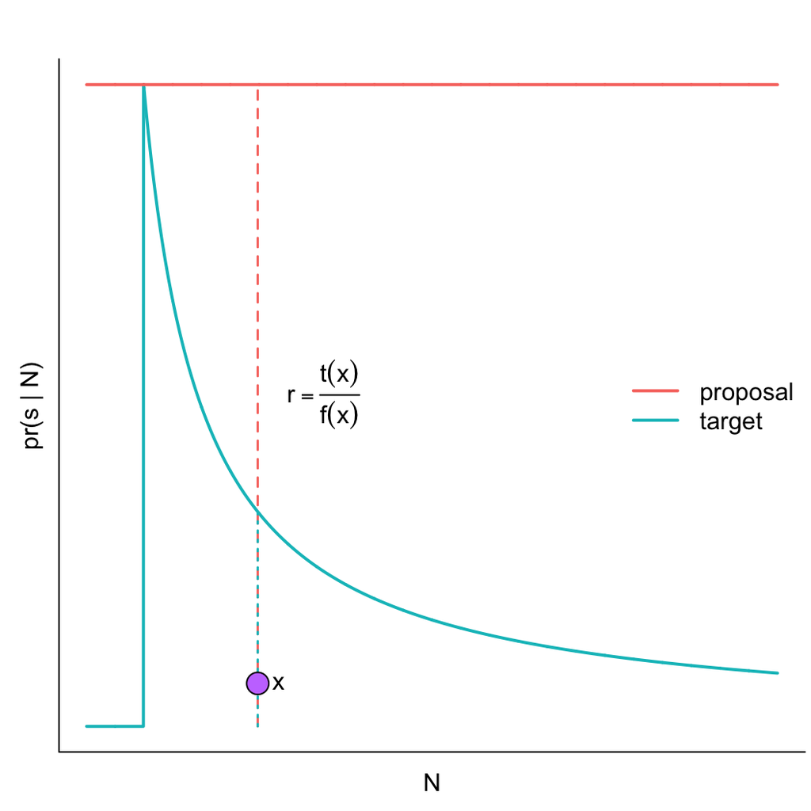

# Rejection sampling

- We have the **target distribution**, $t(N) = pr(s|N)$
- Find an easy-to-sample **proposal distribution**, call it $f(N)$
- Draw a sample $x$ from the proposal distribution, and compute an **acceptance probability**, $r = \frac{t(x)}{f(x)}$
- Accept the sample with probability $r$, reject with probability $1-r$
- This is a VERY inefficient way to explore a distribution

```r
s = 200
target = function(x) dunif(s, 1, x)
proposal = function(x) dunif(x, 1, 1e6)

## this scale will make sure f(x) >= t(x)
scale = target(s) / proposal(s)
candidates = as.integer(runif(1e6, 1, 1e6))
r = target(candidates)/(proposal(candidates) * scale)
## Warning in dunif(s, 1, x): NaNs produced

## uniform numbers between 0 and 1
test = runif(length(r))

## TRUE if r > test; WHY?
accept = ifelse(r > test, TRUE, FALSE)
samples = candidates[accept]
```

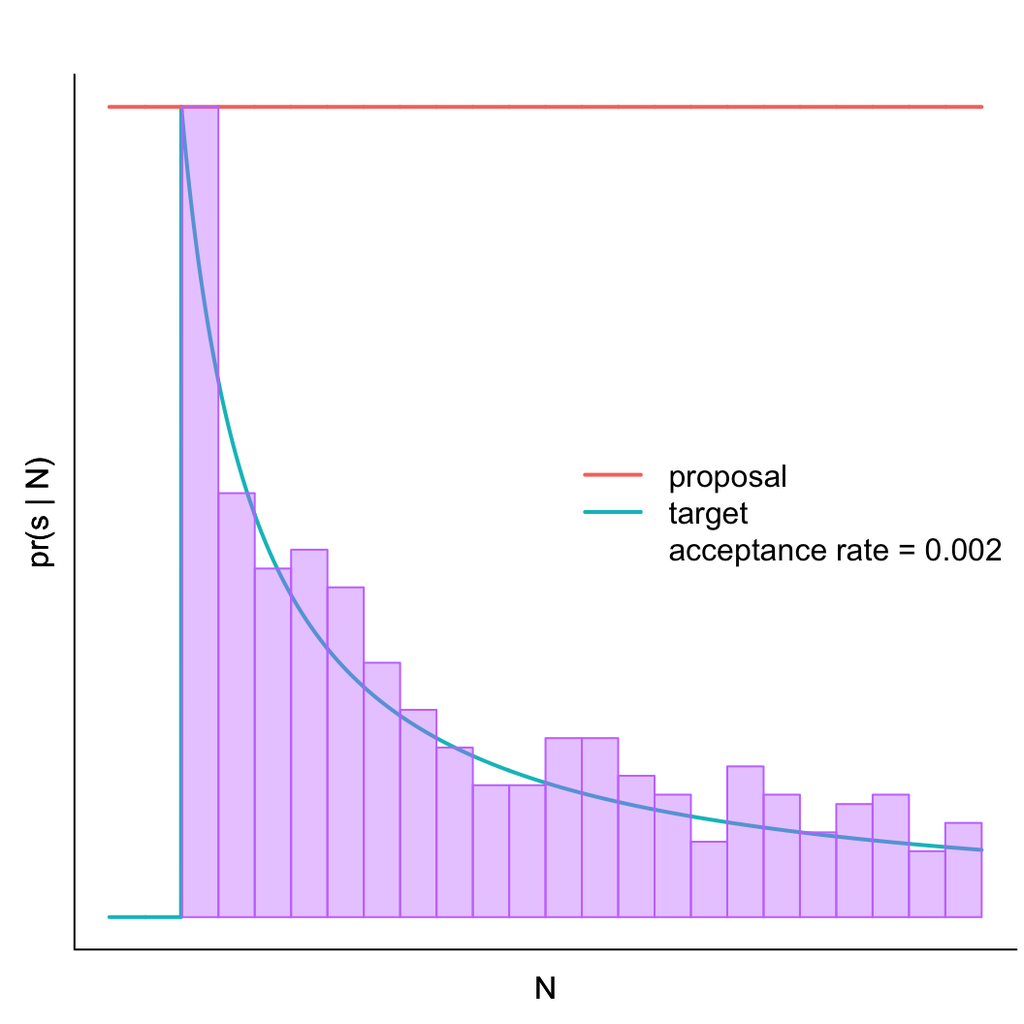

# Markov Chains

# Markov Chain Monte Carlo

- MCMC lets us sample from a posterior distribution
- Individual samples are *not* independent (because proposals are centred around the previous value)
- Run for long enough, we can approximate the shape of the posterior

# Metropolis-Hastings

- The most general MCMC algorithm
- For an unknown (unnormalized) **target distribution** $t(x)$ where we can compute the (proporitonal) height
  - For example, a posterior distribution

$$pr(\theta | X) \propto pr(X | \theta)pr(\theta)$$

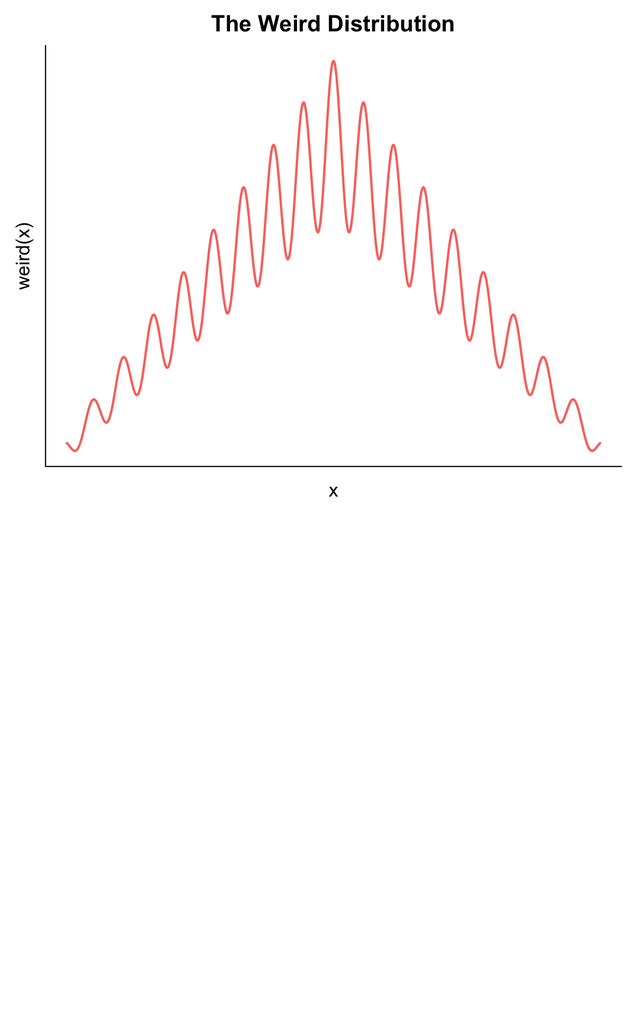

# Metropolis-Hastings: starting value

- For an unknown (unnormalized) **target distribution** $t(x)$ where we can compute the (proporitonal) height
  - For example, a posterior distribution

$$pr(\theta | X) \propto pr(X | \theta)pr(\theta)$$

1. Choose a starting value

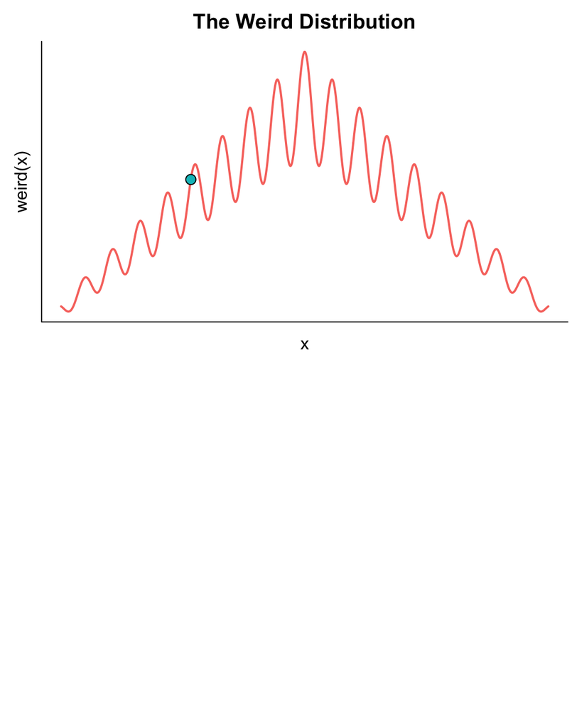

# Metropolis-Hastings: proposal step

- For an unknown (unnormalized) **target distribution** $t(x)$ where we can compute the (proporitonal) height
  - For example, a posterior distribution

$$pr(\theta | X) \propto pr(X | \theta)pr(\theta)$$

1. Choose a starting value $S_0$
2. Propose a candidate $S_{cand}$ by sampling from a proposal distribution **centred around $S_0$**
   - Frequently, $S_{cand} \sim \mathcal{N}(S_t, \sigma_p)$
   - $\sigma_p$ is the **proposal scale** (more on this later)
3. Compute an acceptance probability $r = \frac{t(S_{cand})}{t(S_0)}$
   - in practice: $r = e^{\log t(S_{cand}) - \log t(S_0)}$
   - accept or reject as in rejection sampling
   - If the candidate is better, $r > 1$, always accept

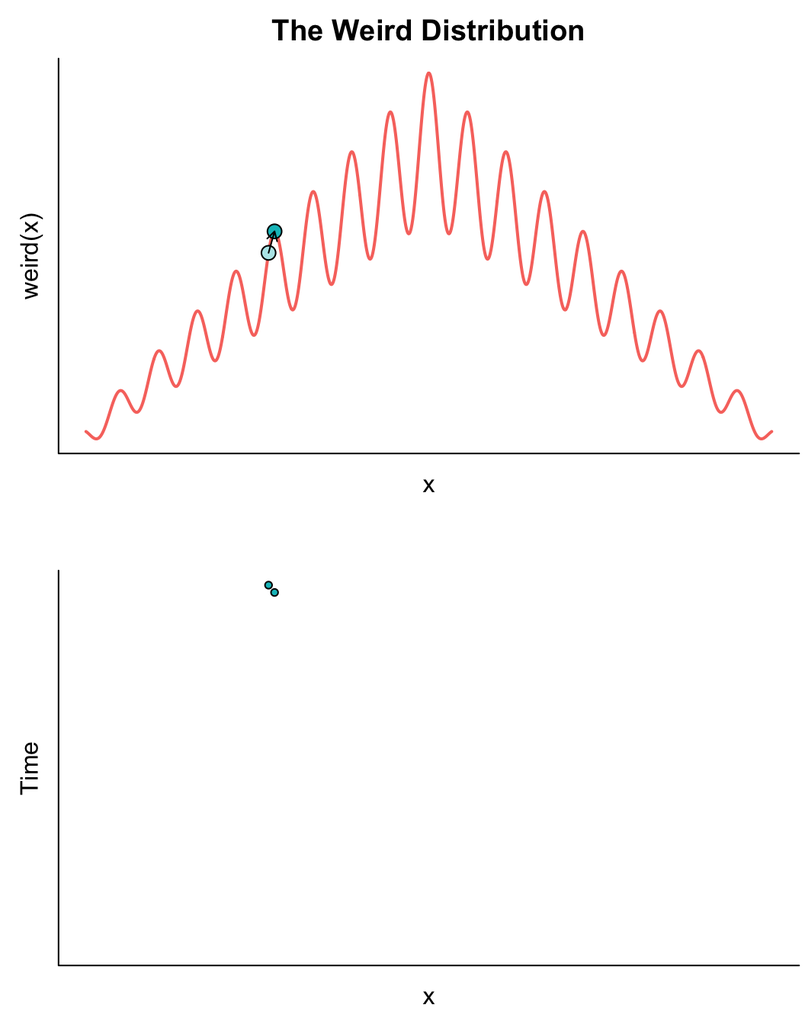

# Metropolis-Hastings: running the chain

- For an unknown (unnormalized) **target distribution** $t(x)$ where we can compute the (proporitonal) height
  - For example, a posterior distribution

$$pr(\theta | X) \propto pr(X | \theta)pr(\theta)$$

1. Choose a starting value $S_0$
2. Propose a candidate $S_{cand}$ by sampling from a proposal distribution **centred around $S_0$**
   - Frequently, $S_{cand} \sim \mathcal{N}(S_t, \sigma_p)$
   - $\sigma_p$ is the **proposal scale** (more on this later)
3. Compute an acceptance probability $r = \frac{t(S_{cand})}{t(S_0)}$
   - in practice: $r = e^{\log t(S_{cand}) - \log t(S_0)}$
   - accept or reject as in rejection sampling
   - If the candidate is better, $r > 1$, always accept
4. Continue; asymptotically, the state of the chain converges on the target distribution

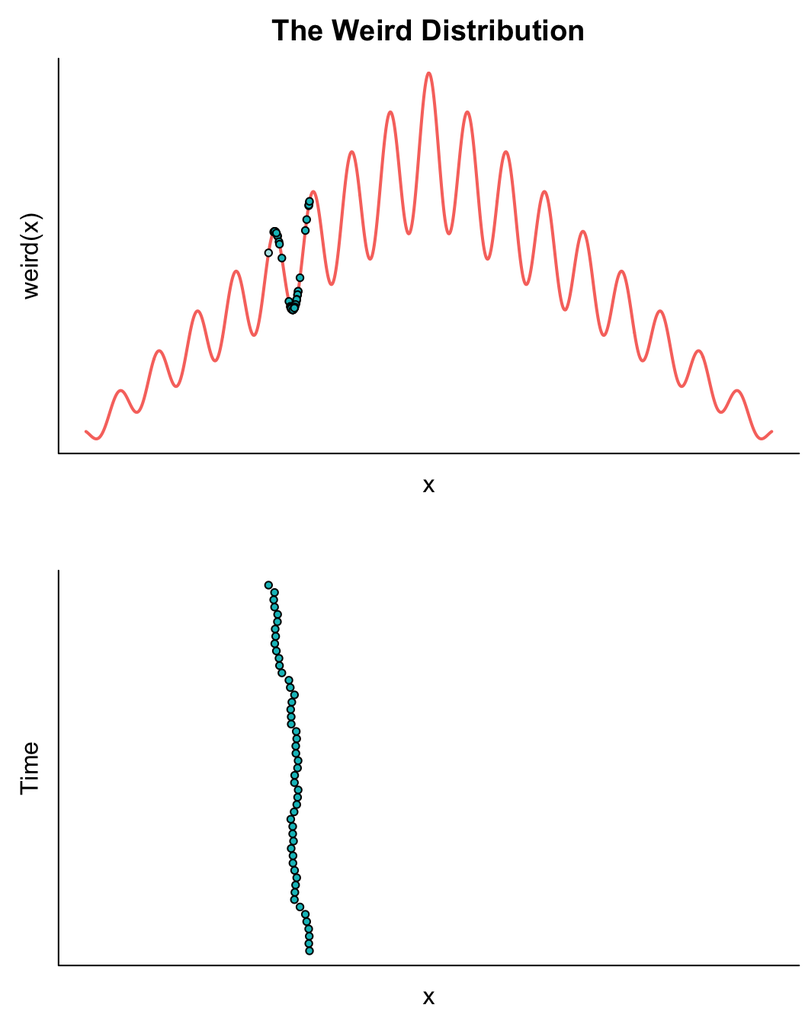

# Metropolis-Hastings: results

- For an unknown (unnormalized) **target distribution** $t(x)$ where we can compute the (proporitonal) height
  - For example, a posterior distribution

$$pr(\theta | X) \propto pr(X | \theta)pr(\theta)$$

1. Choose a starting value $S_0$
2. Propose a candidate $S_{cand}$ by sampling from a proposal distribution **centred around $S_0$**
   - Frequently, $S_{cand} \sim \mathcal{N}(S_t, \sigma_p)$
   - $\sigma_p$ is the **proposal scale** (more on this later)
3. Compute an acceptance probability $r = \frac{t(S_{cand})}{t(S_0)}$
   - in practice: $r = e^{\log t(S_{cand}) - \log t(S_0)}$
   - accept or reject as in rejection sampling
   - If the candidate is better, $r > 1$, always accept
4. Continue; asymptotically, the state of the chain converges on the target distribution

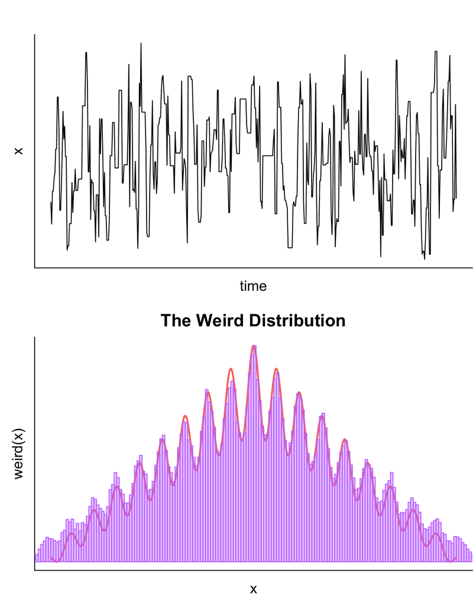

# Metropolis algorithm summary

```
Define log unnormalized posterior (also called target) distribution target(x)
Define proposal sampler: often rnorm(1, state[t-1], prscale)
Define starting value = chain[1]
for i in 2:n_samples
   candidate = proposal(chain[i-1], prscale)
   r = exp( target(candidate) - target(chain[i-1])) ## acceptance probability
   if r > runif(1)  ## coin flip to see if we accept or not
      chain[i] = candidate
   else
      chain[i] = chain[i-1]
```

# Multivariate Metropolis-Hastings

- Logic is the same
- We cannot easily sample from the joint posterior $pr(\theta_1, \theta_2 | X)$
- We can sample from conditional posteriors $pr(\theta_1, | \theta_2, X)$
- Simply sample from parameters one at a time, in random order (see sample code)

# Tuning Metropolis-Hastings

- Proposal variance is essential for efficiency
- Ideally we want acceptance rates around 0.235 for high dimensional problems, closer to 0.5 for univariate
- Can use adaptive samplers (see sample code) to automate selection of proposal variance
- A simple way to implement adaptation:
  - run a chain, at each step, if accepted, scale = scale * 1.1; if rejected scale = scale / 1.1
  - must discard these samples, start chain over with constant scale

# Traceplots

- Traceplots are an important indicator that chains are working efficiently
- Other helpful plots: `mcmc_hist()` and `mcmc_pairs` (multivariate)

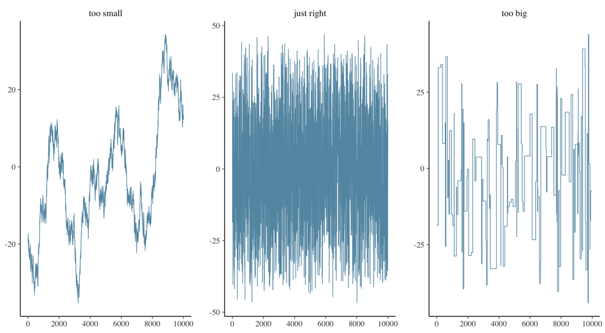

```r
library(bayesplot)
samples = readRDS("misc/traceplt_ex.rds")
mcmc_trace(samples)
```

# Hamiltonian monte carlo

- Only gets a mention here, we won’t implement this
- We will use this when we start using Stan
- HMC imagines the posterior density is a frictionless bowl; more probable locations are lower
- Place a ball on this bowl, give it a shove in a random direction, record everywhere it goes
- The ball curves around the surface, sample from the path
- once the ball slows down past a certain threshold, drop in a new place and shove it again